# Practicle machine learning Final Assignment

## Data

The training data for this project are available here: [link]https://d396qusza40orc.cloudfront.net/predmachlearn/pml-training.csv The test data are available here: [link]https://d396qusza40orc.cloudfront.net/predmachlearn/pml-testing.csv The data for this project come from this source: [link]http://groupware.les.inf.puc-rio.br/har. If you use the document you create for this class for any purpose please cite them as they have been very generous in allowing their data to be used for this kind of assignment.

## What you should submit

The goal of your project is to predict the manner in which they did the exercise. This is the “classe” variable in the training set. You may use any of the other variables to predict with. You should create a report describing how you built your model, how you used cross validation, what you think the expected out of sample error is, and why you made the choices you did. You will also use your prediction model to predict 20 different test cases.

### Packages

```r
# require package caret, rattle
library(caret)
library(rattle)
```

### Get data and clean data

```r
raw_training<-read.csv('https://d396qusza40orc.cloudfront.net/predmachlearn/pml-training.csv',na.strings=c("NA","#DIV/0!", ""))
raw_testing<-read.csv('https://d396qusza40orc.cloudfront.net/predmachlearn/pml-testing.csv',na.strings=c("NA","#DIV/0!", ""))
set.seed(323)
## Remove NA
train<-raw_training[,colSums(is.na(raw_training)) == 0]
test <-raw_testing[,colSums(is.na(raw_testing)) == 0]

## Not every variable is predictors, delete those irrevelent
train_final<-train[,-c(1:7)]
test_final<-test[,-c(1:7)]

## Subset the data for evaluate the performance of different classifiers
division<-createDataPartition(y=train_final$classe, p=0.70, list=FALSE)
subtrain<-train_final[division,]
validation<-train_final[-division,]
dim(subtrain)
```

```
## [1] 13737    53
```

```r
dim(validation)
```

```
## [1] 5885   53
```

```r
dim(test)
```

```
## [1] 20 60
```

## Different classifiers by different methods

1. By using the rpart, treebag and rf methods in caret packages
2. Compare their performance
3. Majorly forcast in decision tree methods

### Tree by rpart

```r
#caret rpart
model_tree1 <-train(classe~.,data=subtrain,method="rpart",tuneLength=20,trControl=trainControl(method="cv", number=10))
```

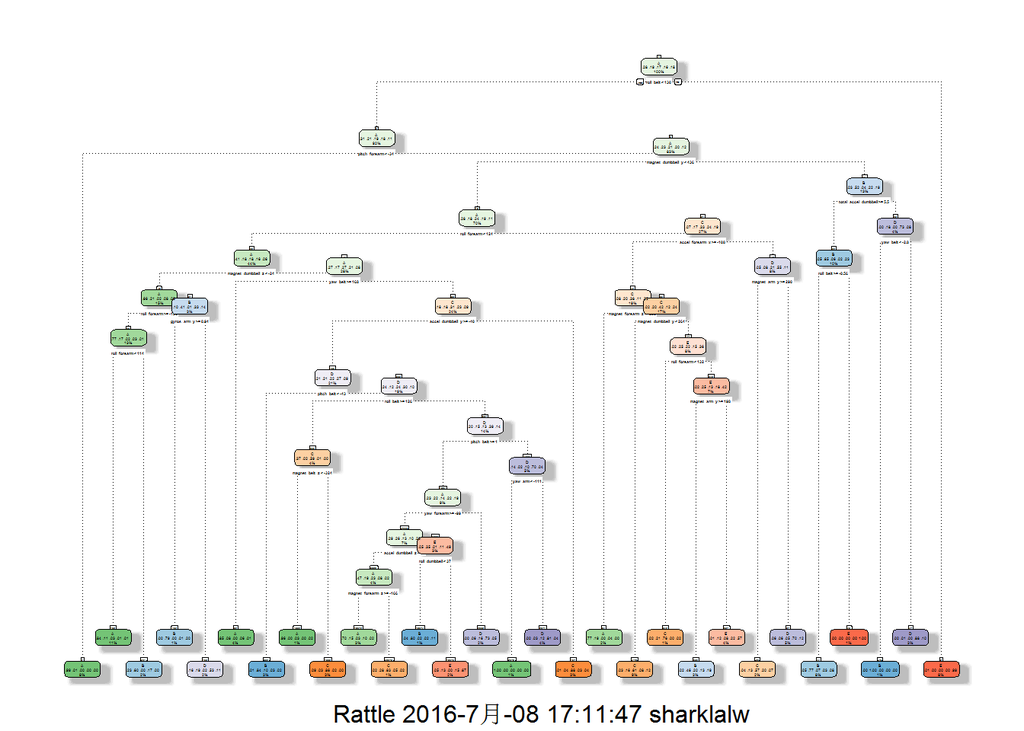

```r
fancyRpartPlot(model_tree1$finalModel)
```

```r
pred_tree1<-predict(model_tree1,newdata=validation,type="raw")
confusionMatrix(pred_tree1,validation$classe)
```

```
## Confusion Matrix and Statistics
##
##           Reference
## Prediction    A    B    C    D    E
##          A 1493  126   21   47    3
##          B   74  720   76   49   86
##          C   40  173  834   68   80
##          D   44   62   86  716  101
##          E   23   58    9   84  812
##
## Overall Statistics
##
##                Accuracy : 0.7774
##                  95% CI : (0.7666, 0.788)
##     No Information Rate : 0.2845
##     P-Value [Acc > NIR] : < 2.2e-16
##
##                   Kappa : 0.7186
##  Mcnemar's Test P-Value : < 2.2e-16
##
## Statistics by Class:
##
##                      Class: A Class: B Class: C Class: D Class: E
## Sensitivity            0.8919   0.6321   0.8129   0.7427   0.7505
## Specificity            0.9532   0.9399   0.9257   0.9405   0.9638
## Pos Pred Value         0.8834   0.7164   0.6979   0.7096   0.8235
## Neg Pred Value         0.9569   0.9141   0.9591   0.9491   0.9449
## Prevalence             0.2845   0.1935   0.1743   0.1638   0.1839
## Detection Rate         0.2537   0.1223   0.1417   0.1217   0.1380
## Detection Prevalence   0.2872   0.1708   0.2031   0.1715   0.1675
## Balanced Accuracy      0.9225   0.7860   0.8693   0.8416   0.8571
```

### Bagging the tree

- The accuracy of rpart is 0.77, what if bagging the tree?

```r
model_tree2 <-train(classe~.,data=subtrain,method="treebag",tuneLength=20,trControl=trainControl(method="cv", number=10))
pred_tree2<-predict(model_tree2,newdata=validation,type="raw")
confusionMatrix(pred_tree2,validation$classe)
```

```
## Confusion Matrix and Statistics
##
##           Reference
## Prediction    A    B    C    D    E
##          A 1664   11    2    1    0
##          B    4 1109    6    1    9
##          C    5   17 1005   10    3
##          D    0    2   13  949    3
##          E    1    0    0    3 1067
##
## Overall Statistics
##
##                Accuracy : 0.9845
##                  95% CI : (0.981, 0.9875)
##     No Information Rate : 0.2845
##     P-Value [Acc > NIR] : < 2.2e-16
##
##                   Kappa : 0.9804
##  Mcnemar's Test P-Value : 0.006294
##
## Statistics by Class:
##
##                      Class: A Class: B Class: C Class: D Class: E
## Sensitivity            0.9940   0.9737   0.9795   0.9844   0.9861
## Specificity            0.9967   0.9958   0.9928   0.9963   0.9992
## Pos Pred Value         0.9917   0.9823   0.9663   0.9814   0.9963
## Neg Pred Value         0.9976   0.9937   0.9957   0.9969   0.9969
## Prevalence             0.2845   0.1935   0.1743   0.1638   0.1839
## Detection Rate         0.2828   0.1884   0.1708   0.1613   0.1813
## Detection Prevalence   0.2851   0.1918   0.1767   0.1643   0.1820
## Balanced Accuracy      0.9954   0.9847   0.9862   0.9904   0.9927
```

### Random forest

- The accuracy of bagging the tree is increasing, what if bagging the tree as random forest?

```r
model_rf <-train(classe~.,data=subtrain,method="rf",trControl=trainControl(method="cv", number=10))
pred_rf<-predict(model_rf,newdata=validation,type="raw")
confusionMatrix(pred_rf,validation$classe)
```

```
## Confusion Matrix and Statistics
##
##           Reference
## Prediction    A    B    C    D    E
##          A 1672    5    0    0    0
##          B    2 1131    2    0    0
##          C    0    3 1015    7    4
##          D    0    0    9  956    2
##          E    0    0    0    1 1076
##
## Overall Statistics
##
##                Accuracy : 0.9941
##                  95% CI : (0.9917, 0.9959)
##     No Information Rate : 0.2845
##     P-Value [Acc > NIR] : < 2.2e-16
##
##                   Kappa : 0.9925
##  Mcnemar's Test P-Value : NA
##
## Statistics by Class:
##
##                      Class: A Class: B Class: C Class: D Class: E
## Sensitivity            0.9988   0.9930   0.9893   0.9917   0.9945
## Specificity            0.9988   0.9992   0.9971   0.9978   0.9998
## Pos Pred Value         0.9970   0.9965   0.9864   0.9886   0.9991
## Neg Pred Value         0.9995   0.9983   0.9977   0.9984   0.9988
## Prevalence             0.2845   0.1935   0.1743   0.1638   0.1839
## Detection Rate         0.2841   0.1922   0.1725   0.1624   0.1828
## Detection Prevalence   0.2850   0.1929   0.1749   0.1643   0.1830
## Balanced Accuracy      0.9988   0.9961   0.9932   0.9947   0.9971
```

```r
# importance of each predictor
importance(model_rf$finalModel)
```

```
##                      MeanDecreaseGini
## roll_belt                  1405.70012
## pitch_belt                  622.13403
## yaw_belt                    776.56683
## total_accel_belt             39.59598
## gyros_belt_x                 40.89261
## gyros_belt_y                 47.06082
## gyros_belt_z                171.43154
## accel_belt_x                 35.45543
## accel_belt_y                 34.72792
## accel_belt_z                218.65658
## magnet_belt_x               162.02490
## magnet_belt_y               204.56215
## magnet_belt_z               236.12655
## roll_arm                    135.15209
## pitch_arm                    85.41277
## yaw_arm                     170.68115
## total_accel_arm              43.57273
## gyros_arm_x                  61.39188
## gyros_arm_y                  81.54156
## gyros_arm_z                  22.98366
## accel_arm_x                 101.11486
## accel_arm_y                  65.26024
## accel_arm_z                  54.93036
## magnet_arm_x                106.91668
## magnet_arm_y                106.54646
## magnet_arm_z                 93.31921
## roll_dumbbell               279.28683
## pitch_dumbbell               69.99282
## yaw_dumbbell                128.34648
## total_accel_dumbbell        215.84034
## gyros_dumbbell_x             58.57766
## gyros_dumbbell_y            125.31929
## gyros_dumbbell_z             37.91212
## accel_dumbbell_x            102.56200
## accel_dumbbell_y            314.11390
## accel_dumbbell_z            223.56321
## magnet_dumbbell_x           240.20126
## magnet_dumbbell_y           629.57394
## magnet_dumbbell_z           619.59160
## roll_forearm                629.39454
## pitch_forearm               879.15792
## yaw_forearm                 113.56450
## total_accel_forearm          43.84034
## gyros_forearm_x              27.14125
## gyros_forearm_y              57.49773
## gyros_forearm_z              38.23942
## accel_forearm_x             263.18205
## accel_forearm_y              72.65516
## accel_forearm_z             137.43931
## magnet_forearm_x             97.56894
## magnet_forearm_y            109.09575
## magnet_forearm_z            223.37440
```

### Prediction of test set

- Apply the best performance classifier (*modelrf*) into the test set

```r
pred_test<-predict(model_rf,newdata=test_final,type="raw")
print(pred_test)
```

```
##  [1] B A B A A E D B A A B C B A E E A B B B
## Levels: A B C D E
```